# Проект SQL: Почему сотрудники увольняются?

Помазкова Арина, atpomazkova

## Задача

Задача – **проанализировать отток сотрудников из компании**. 3аказчику, то есть работодателю (в частности, его руководству и HR-отделу), необходимо выявить свои слабые стороны, чтобы понять, почему работники не хотят продолжать с ним сотрудничать. Эта аналитика может быть необходима, чтобы:

1. Уменьшить «текучку кадров»;
2. Сократить убытки от ухода ценных работников;
3. Улучшать условия труда для привлечения новых сотрудников;
4. В долгосрочной перспективе сформировать репутацию надёжного работодателя и т.д.

Для выполнения этой цели заказчику необходимы:

1. Подробная аналитка основных причин оттока сотрудников;
2. Выявление «групп риска», наиболее склонных к уходу из компании;
3. Представление возможных решений и изменений в соответствии с причинами оттока.

Именно эти задачи решает данная работа.

## Анализ

### Данные и логика анализа

Посмотрим на распределение оттока по возрасту сотрудников.

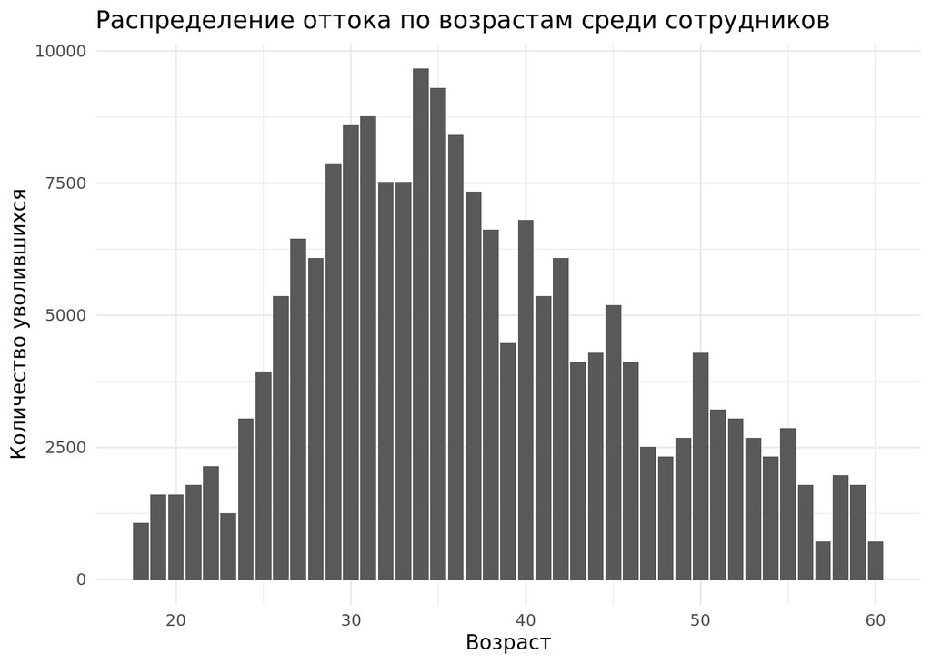

```r
#подключение к базе данных про сотрудников компании
library(DBI)
con <- dbConnect(ClickHouseHTTP::ClickHouseHTTP(),
                 user='studentminor',
                 password='DataMinorHSE!2023',
                 dbname='employee',
                 host='rc1a-i6ui9dhblsq8rgdo.mdb.yandexcloud.net',
                 port = 8443,
                 https=TRUE,
                 ssl_verifypeer=FALSE)

library(dplyr)
library(knitr)
library(kableExtra)

data3 = dbGetQuery(con, "SELECT Attrition, Age,
                        CASE
                            WHEN Age > 35 THEN 'old'
                            ELSE 'young'
                            END AS group
                        FROM portfolio
                        INNER JOIN profile USING(EmployeeNumber)")

library(ggplot2)

ggplot(data3) +
  geom_col(aes(x = Age, y = sum(Attrition))) +
  labs(title = 'Распределение оттока по возрастам среди сотрудников') +
  xlab('Возраст') +
  ylab('Количество уволившихся') +
  theme_minimal()
```

Наиболее интересным мне показался **сегмент молодых работников до 35 лет включительно** (эту возрастную группу принято считать молодёжью). В процентном соотношении эта подгруппа чаще уходит из компании: 22.8% молодых специалистов покидают компанию по сравнению с 11.5% работников, старше 35 лет. Интересно посмотреть, с чем связан более активный отток молодых кадров.

```r
#разведка
data1 = dbGetQuery(con, "SELECT Attrition,
                        ROUND(COUNT(*)/(SELECT COUNT(*) FROM portfolio
                                  INNER JOIN profile USING(EmployeeNumber)
                                  WHERE Age <=35)*100, 2) as prop
                        FROM portfolio
                        INNER JOIN profile USING(EmployeeNumber)
                        WHERE Age <= 35
                        GROUP BY Attrition")

data2 = dbGetQuery(con, "SELECT Attrition,
                        ROUND(COUNT(*)/(SELECT COUNT(*) FROM portfolio
                                  INNER JOIN profile USING(EmployeeNumber)
                                  WHERE Age <=35)*100, 2) as prop
                        FROM portfolio
                        INNER JOIN profile USING(EmployeeNumber)
                        WHERE Age > 35
                        GROUP BY Attrition")

knitr::kable(data1, align = "ccc", caption = 'Процент ушедших и оставшихся сотрудников до 35 лет') %>% kable_classic(full_width = T, html_font = "Cambria") %>% kableExtra::kable_minimal()
```

Процент ушедших и оставшихся сотрудников до 35 лет

| Attrition | prop |
| --- | --- |
| 0 | 77.25 |
| 1 | 22.75 |

```r
knitr::kable(data2, align = "ccc", caption = 'Процент ушедших и оставшихся сотрудников старше 35 лет') %>% kable_classic(full_width = T, html_font = "Cambria") %>% kableExtra::kable_minimal()
```

Процент ушедших и оставшихся сотрудников старше 35 лет

[output not shown]

В финальном датасете для построения предсказательной модели оставляем только работников до 35 лет включительно. Для предсказания будут использованы 9 переменных: демографические показатели (пол и семейное положение), все переменные, связанные с удовлетворённостью работой (в том числе коллективом и рабочей средой), показатели переработки (work-life balance и переработка), а также все переменные, связанные с оплатой труда (годовой доход и повышение зарплаты). Предполагается, что именно эти факторы влияют на отток молодых сотрудников из компании.

Дополнительно в финальном датасете были преобразованы все номинальные переменные в категориальные.

```r
data = dbGetQuery(con, 'SELECT Gender, MaritalStatus, WorkLifeBalance,
                        Attrition, EnvironmentSatisfaction,
                        JobSatisfaction, MonthlyIncome,
                        OverTime, PercentSalaryHike, RelationshipSatisfaction
                        FROM portfolio
                        INNER JOIN profile USING(EmployeeNumber)
                        WHERE Age <= 35')

data = data %>% mutate_if(is.character, as.factor)
data$Attrition = data$Attrition %>% as.factor()

dbDisconnect(con)
```

### Модель

Так как перед нами стоит задача классификации, то для предсказания напрашиваются два метода: логистическая регрессия и дерево решений. Посмотрим на показатели качества двух моделей. Учтём, что в данном случае нам особенно важен показатель specificity, так как наши данные несбалансированы и в датасете гораздо больше случаев, когда работники не уходили из компании.

Cначала смотрим показатели качества модели дерева решений.

```r
library(tidymodels)
library(caret)
library(rsample)

set.seed(134)
Split = initial_split(data, prop = 0.8)
train = training(Split)
test = testing(Split)

#дерево решений
treemodel = decision_tree(mode = 'classification', engine = 'rpart')
set.seed(134)
tree = treemodel %>% fit(Attrition~., data = train)
predtree = predict(tree, test)

confusionMatrix(predtree$.pred_class, test$Attrition)
```

```
## Confusion Matrix and Statistics
##
##           Reference
## Prediction  0  1
##          0 74 12
##          1 11  8
##
##                Accuracy : 0.781
##                  95% CI : (0.6897, 0.8558)
##     No Information Rate : 0.8095
##     P-Value [Acc > NIR] : 0.8096
##
##                   Kappa : 0.2759
##
##  Mcnemar's Test P-Value : 1.0000
##
##             Sensitivity : 0.8706
##             Specificity : 0.4000
##          Pos Pred Value : 0.8605
##          Neg Pred Value : 0.4211
##              Prevalence : 0.8095
##          Detection Rate : 0.7048
##    Detection Prevalence : 0.8190
##       Balanced Accuracy : 0.6353
##
##        'Positive' Class : 0
##
```

```r
#accuracy = 0.781 spec = 0.4
```

Теперь логистической регрессии.

```r
#логичтическая регрессия
model = logistic_reg()
set.seed(134)
logreg = model %>% fit(Attrition~., data = train)
predlog = predict(logreg, test)

confusionMatrix(predlog$.pred_class, test$Attrition)
```

```
## Confusion Matrix and Statistics
##
##           Reference
## Prediction  0  1
##          0 78 11
##          1  7  9
##
##                Accuracy : 0.8286
##                  95% CI : (0.7427, 0.8951)
##     No Information Rate : 0.8095
##     P-Value [Acc > NIR] : 0.3631
##
##                   Kappa : 0.3981
##
##  Mcnemar's Test P-Value : 0.4795
##
##             Sensitivity : 0.9176
##             Specificity : 0.4500
##          Pos Pred Value : 0.8764
##          Neg Pred Value : 0.5625
##              Prevalence : 0.8095
##          Detection Rate : 0.7429
##    Detection Prevalence : 0.8476
##       Balanced Accuracy : 0.6838
##
##        'Positive' Class : 0
##
```

```r
#accuracy = 0.8286 spec= 0.45
```

Итак, по результатам построения первичных моделей показатели первой оказались хуже, чем у второй (accuracy = 0.781 и specificity = 0.4, accuracy = 0.8286 и specificity = 0.45 соответсвенно). Поэтому выбираем **модель логистической регрессии**.

Постараемся улучшить specificity с помощью обучения модели на данных с дублирующимися наблюдениями из малочисленного класса. **Используем up-sampling**.

```r
set.seed(134)
ds_up <- recipe(~., data = train) %>%
  themis::step_upsample(Attrition) %>%
  prep(training = train, retain = TRUE) %>%
  bake(new_data = NULL)

set.seed(134)
up_log_model = model %>% fit(Attrition ~., ds_up)

pred_up = predict(up_log_model, test)

confusionMatrix(pred_up$.pred_class, test$Attrition)
```

```
## Confusion Matrix and Statistics
##
##           Reference
## Prediction  0  1
##          0 62  2
##          1 23 18
##
##                Accuracy : 0.7619
##                  95% CI : (0.6689, 0.8396)
##     No Information Rate : 0.8095
##     P-Value [Acc > NIR] : 0.9112
##
##                   Kappa : 0.4491
##
##  Mcnemar's Test P-Value : 6.334e-05
##
##             Sensitivity : 0.7294
##             Specificity : 0.9000
##          Pos Pred Value : 0.9687
##          Neg Pred Value : 0.4390
##              Prevalence : 0.8095
##          Detection Rate : 0.5905
##    Detection Prevalence : 0.6095
##       Balanced Accuracy : 0.8147
##
##        'Positive' Class : 0
##
```

```r
#accuracy = 0.76 spec= 0.9
```

Несмотря на то, что показатель accuracy уменьшился, с помощью up-sampling мы значительно улучшили specificity.

Посмотрим, какие переменные в предсказании имеют большую значимость.

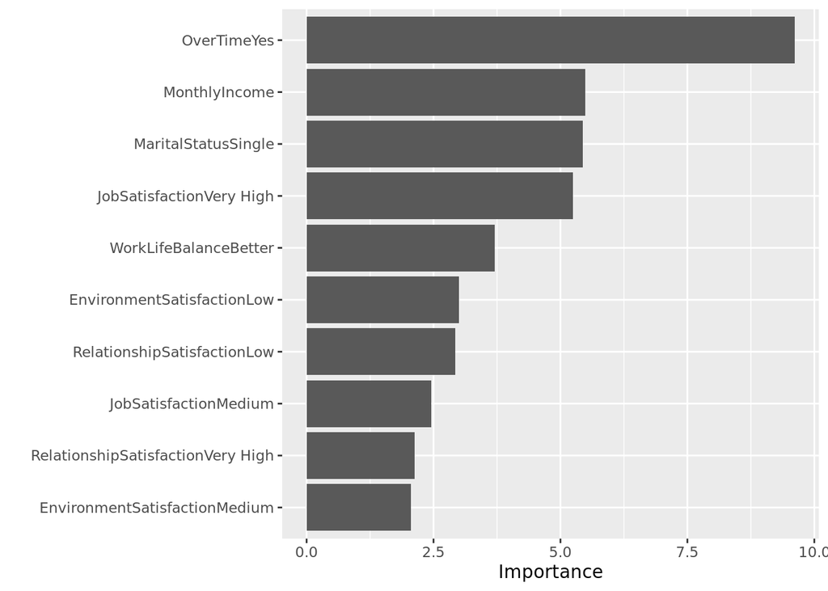

```r
library(vip)
vip(up_log_model)
```

### Симуляция

Смоделируем ситуацию, в которой эти показатели изменились. Предположим, что *в 30% случаев работники перестали перерабатывать*, например:

1. После введения корпоративного запрета на пребывание на рабочем месте при достижении определённого количества сверхурочных часов;
2. При регулярном мониторинге состояния работников из группы риска и оказании необходимой психологической помощи перерабатывающим работникам;
3. При введении обязательного денежного вознаграждения за переработку и т. д.

Также предположим, что *в 30% случаях удовлетворённость рабочей средой повысилась* (в 20% с низкой на среднюю, в 10% с низкой на высокую). Такая ситуация возможна, например:

1. После капитального ремонта офиса;
2. При развитии зон отдыха на рабочем месте;
3. После обновлении рабочей техники и т. д.

Посмотрим, насколько сократилось количество уволившихся молодых сотрудников (в процентах) при **возможном** введении предложенных изменений.

```r
test2 = test
set.seed(134)
test2$OverTime[test2$OverTime == "Yes"] =
  sample(c("Yes", "No"),
         size = length(test2$OverTime[test2$OverTime == "No"]),
         replace = T, prob = c(0.7, 0.3))

set.seed(134)
test2$EnvironmentSatisfaction[test2$EnvironmentSatisfaction == "Low"] =
  sample(c("Low", "Medium", "High"),
         size =
      length(test2$EnvironmentSatisfaction[test2$EnvironmentSatisfaction == "Low"]),
         replace = T, prob = c(0.7, 0.2, 0.1))

pred_sim = predict(up_log_model, test2)


a = (length(pred_up$.pred_class[pred_up$.pred_class == 1])/length(pred_up$.pred_class))*100

b = (length(pred_sim$.pred_class[pred_sim$.pred_class == 1])/length(pred_sim$.pred_class))*100

paste(round(a-b, 2), "%")
```

```
## [1] "11.43 %"
```

Как мы видим, согласно предсказанию, при изменениях показателей переработки и удовлетворённости рабочей средой **количество уволившиxся сотрудников уменьшается на 11%.**

### Дэшборд

В дэшборде собрана информация о специфике подгруппы работников до 35 лет. Она обобщает информацию об основных причинах ухода молодых сотрудников, предоставляет сравнение распределения по возрастам оставшихся и ушедших внутри класса, а также иллюстрирует возможность уменьшения увольнений. Такое обобщение будет полезно работодателю, так как дэшборд визуализирует влияние различных факторов на отток кадров из этой «группы риска». Всего можно выделить 5 элементов:

- **Левая колонка: Установка условий для графика распределения увольнений среди работников до 35 лет.** Включает в себя выбор уровня удовлетворённости рабочей средой, наличия переработок и статуса сотрудников – ушёл или нет. Эта панель управления позволяет посмотреть на влияние самых значимых факторов как по отдельности, так и в совокупности.
- **По центру: График распределение оттока среди сотрудников до 35 лет.** Основной график, на котором происходят измнения в зависимости от выбранных условий.
- **Правая колонка верх: Процент оттока молодых кадров.** 3начение доли работников до 35 лет, которые покинули компанию. 22% – это достаточно большой процент оттока даже в крупных компаниях.
- **Правая колонка центр: График значимости переменных для предсказания оттока.** Дополнительный график, визуализирующий степень влияния разных факторов на уход молодых сотрудников.
- **Правая колонка низ: Процент уменьшения оттока после введения изменений.** В данной работе было предложено сократить переработку и неудовлетворённость рабочей средой на 30%. После введения предложенных изменений отток молодых кадров может уменьшиться на 11%.

## Общие выводы

Было проведено исследование оттока сотрудников в некоторой компании. 22% работников до 35 лет выбирают уйти из компании – такой показатель говорит о проблемах внутри предприятия, которые должны быть исправлены во избежание убытков из-за оттока ценных и молодых кадров.

В рамках данной работы было выявлено, что при повышении удовлетворённости рабочей средой и значительного сокращения переработок можно достичь уменьшения оттока на 11%.